# L09 — Evaluative Exercise 1

Block 1 · Descriptive Statistics · In-class exercise

# 1 The data

`L09_workshops.csv` records one month of activity for the 320 artisan workshops that belong to a regional consortium. Every statement made below describes these 320 workshops exactly: nothing is inferred about workshops outside the file.

| Column | Meaning |
| --- | --- |
| `workshop_id` | Identifier of the workshop |
| `province_code` | Province of registration, coded 1 to 4 |
| `craft` | Craft practised: Ceramics, Leather, Woodwork, Textiles |
| `qualification` | Level held by the head of the workshop: Apprentice, Craftsman, Master |
| `years_active` | Completed years the workshop has been active |
| `price_per_piece` | List price of a piece, averaged over the workshop’s catalogue, in euros |
| `pieces_sold` | Pieces sold during the month |
| `quality_score` | Consortium quality score for the month, from 1 to 5 |
| `monthly_revenue` | Total takings for the month, in euros: sales net of discounts, plus commissions, courses and repairs |
| `exports` | Whether the workshop sold abroad during the month |

Because of discounts on one side and non-sales income on the other, `monthly_revenue` is not the product of `price_per_piece` and `pieces_sold`.

Four exercises. Fill the chunks; the questions that close each one are there for you to check your own understanding, and are not handed in.

```r
workshops <- read.csv("L09_workshops.csv", stringsAsFactors = FALSE)

str(workshops)
```

```
## 'data.frame':    320 obs. of  10 variables:
##  $ workshop_id    : chr  "W001" "W002" "W003" "W004" ...
##  $ province_code  : int  3 2 3 3 2 4 1 3 3 3 ...
##  $ craft          : chr  "Ceramics" "Ceramics" "Ceramics" "Ceramics" ...
##  $ qualification  : chr  "Master" "Craftsman" "Master" "Apprentice" ...
##  $ years_active   : int  17 6 12 2 7 2 7 3 5 1 ...
##  $ price_per_piece: num  88.9 71 82.2 53.4 69.2 ...
##  $ pieces_sold    : int  90 47 122 123 50 70 113 122 82 138 ...
##  $ quality_score  : num  4.9 3.7 4.7 5 4.3 4.8 NA 4.7 4.8 4.6 ...
##  $ monthly_revenue: num  5410 6440 5137 4622 7336 ...
##  $ exports        : chr  "yes" "no" "no" "no" ...
```

# 2 Exercise 1 — Measurement scales, position and shape

1. Run `summary()` on the data frame and identify the column with missing values and how many there are.
2. Compute `mean(workshops$province_code)`. Then convert `qualification` into an **ordered** factor with its levels in the correct order and check it with `table()`.
3. Compute mean, median and the five-number summary of `monthly_revenue`, and the sample skewness $\frac{1}{n}\sum_i z_i^3$, where $z_i$ is the standardized variable computed with `mean()` and `sd()`.
4. Recompute mean and median after removing the largest workshop, with `workshops$monthly_revenue[-which.max(workshops$monthly_revenue)]`, and compare the two displacements.

```r
summary(workshops)
```

```
##     workshop_id  province_code         craft       qualification
##  Length   :320   Min.   :1.000   Length   :320   Length   :320
##  N.unique :320   1st Qu.:1.000   N.unique :  4   N.unique :  3
##  N.blank  :  0   Median :2.000   N.blank  :  0   N.blank  :  0
##  Min.nchar:  4   Mean   :2.134   Min.nchar:  7   Min.nchar:  6
##  Max.nchar:  4   3rd Qu.:3.000   Max.nchar:  8   Max.nchar: 10
##                  Max.   :4.000
##
##   years_active    price_per_piece  pieces_sold    quality_score
##  Min.   : 1.000   Min.   :36.05   Min.   : 20.0   Min.   :2.700
##  1st Qu.: 3.000   1st Qu.:53.78   1st Qu.: 93.0   1st Qu.:4.400
##  Median : 4.000   Median :62.24   Median :122.5   Median :4.700
##  Mean   : 6.628   Mean   :64.21   Mean   :119.7   Mean   :4.594
##  3rd Qu.: 9.000   3rd Qu.:74.90   3rd Qu.:146.0   3rd Qu.:4.900
##  Max.   :22.000   Max.   :96.32   Max.   :216.0   Max.   :5.000
##                                                   NAs    :11
##  monthly_revenue        exports
##  Min.   :  831.5   Length   :320
##  1st Qu.: 4730.3   N.unique :  2
##  Median : 6879.9   N.blank  :  0
##  Mean   : 7905.5   Min.nchar:  2
##  3rd Qu.: 9828.2   Max.nchar:  3
##  Max.   :24600.8
##
```

```r
# Report only columns that contain missing observations.
missing_counts <- colSums(is.na(workshops))
print(missing_counts[missing_counts > 0])
```

```
## quality_score
##            11
```

```r
stopifnot(nrow(workshops) == 320, ncol(workshops) == 10,
          missing_counts["quality_score"] == 11)

mean(workshops$province_code)
```

```
## [1] 2.134375
```

```r
workshops$qualification <- factor(
  workshops$qualification,
  levels = c("Apprentice", "Craftsman", "Master"),
  ordered = TRUE
)
levels(workshops$qualification)
```

```
## [1] "Apprentice" "Craftsman"  "Master"
```

```r
is.ordered(workshops$qualification)
```

```
## [1] TRUE
```

```r
table(workshops$qualification)
```

```
##
## Apprentice  Craftsman     Master
##        135        104         81
```

```r
revenue <- workshops$monthly_revenue
revenue_mean <- mean(revenue)
revenue_median <- median(revenue)
z <- (revenue - mean(revenue)) / sd(revenue)
revenue_skewness <- mean(z^3)

print(c(Mean_EUR = revenue_mean, Median_EUR = revenue_median,
        Sample_skewness = revenue_skewness))
```

```
##        Mean_EUR      Median_EUR Sample_skewness
##     7905.485594     6879.860000        1.061224
```

```r
print(setNames(fivenum(revenue),
               c("Minimum", "Lower hinge", "Median", "Upper hinge", "Maximum")))
```

```
##     Minimum Lower hinge      Median Upper hinge     Maximum
##      831.47     4715.83     6879.86     9860.83    24600.82
```

```r
# This expression removes exactly one observation; keep the full dataset intact.
revenue_without_largest <-
  workshops$monthly_revenue[-which.max(workshops$monthly_revenue)]
stopifnot(length(revenue_without_largest) == length(revenue) - 1)
mean_without_largest <- mean(revenue_without_largest)
median_without_largest <- median(revenue_without_largest)

print(data.frame(
  Statistic = c("Mean (EUR)", "Median (EUR)"),
  Full_data = c(revenue_mean, revenue_median),
  Largest_removed = c(mean_without_largest, median_without_largest),
  Change_removed_minus_full = c(mean_without_largest - revenue_mean,
                               median_without_largest - revenue_median)
))
```

```
##      Statistic Full_data Largest_removed Change_removed_minus_full
## 1   Mean (EUR)  7905.486        7853.149                 -52.33647
## 2 Median (EUR)  6879.860        6872.780                  -7.08000
```

> **(a)** Classify `province_code`, `qualification`, `years_active` and `monthly_revenue` on the four measurement scales, and state for each the highest admissible measure of centre. Why did R return a number for the mean of `province_code`? **(b)** What does the sign of the skewness, together with the relative position of mean and median, say about the distribution of the revenue? **(c)** Which of the two summaries moved when the largest workshop was removed, and which property accounts for it?

# 3 Exercise 2 — Variability and concentration

1. Compute the standard deviation and the IQR of `monthly_revenue`, and the coefficient of variation $s/\bar{x}$ of `monthly_revenue`, `pieces_sold` and `price_per_piece`.
2. For $k = 1.5, 2, 3$, compute the observed proportion of values within $k$ standard deviations of the mean and compare it with the Bienaymé–Chebyshev bound $1 - 1/k^2$.
3. Draw the Lorenz curve of `monthly_revenue` and compute the Gini index as twice the area between the diagonal and the curve:

```r
x <- sort(workshops$monthly_revenue)
p <- (0:length(x)) / length(x)          # cumulative share of workshops
q <- c(0, cumsum(x)) / sum(x)           # cumulative share of total revenue
plot(p, q, type = "l"); abline(0, 1, lty = 2)

area <- sum(diff(p) * (head(q, -1) + tail(q, -1)) / 2)
1 - 2 * area
```

Read off the share of the total taken by the poorer half and by the top decile.

4. Draw the histogram of `monthly_revenue` with `breaks = 10` and with `breaks = 60`. Assign each call to an object and report, for both, the number of classes actually drawn, `length(h$counts)`, and their width, `diff(h$breaks)[1]`.

```r
revenue <- workshops$monthly_revenue
print(c(SD_EUR = sd(revenue), IQR_EUR = IQR(revenue)))
```

```
##   SD_EUR  IQR_EUR
## 4327.060 5097.975
```

```r
cv_variables <- c("monthly_revenue", "pieces_sold", "price_per_piece")
cv <- sapply(workshops[cv_variables], function(x) sd(x) / mean(x))
print(data.frame(Variable = names(cv), CV = unname(cv)))
```

```
##          Variable        CV
## 1 monthly_revenue 0.5473491
## 2     pieces_sold 0.3202583
## 3 price_per_piece 0.2260644
```

```r
k <- c(1.5, 2, 3)
observed_proportion <- sapply(k, function(ki) {
  mean(abs(revenue - mean(revenue)) <= ki * sd(revenue))
})
chebyshev_bound <- 1 - 1 / k^2
print(data.frame(
  k = k,
  Observed_proportion = observed_proportion,
  Chebyshev_lower_bound = chebyshev_bound,
  Observed_minus_bound = observed_proportion - chebyshev_bound
))
```

```
##     k Observed_proportion Chebyshev_lower_bound Observed_minus_bound
## 1 1.5            0.893750             0.5555556            0.3381944
## 2 2.0            0.943750             0.7500000            0.1937500
## 3 3.0            0.990625             0.8888889            0.1017361
```

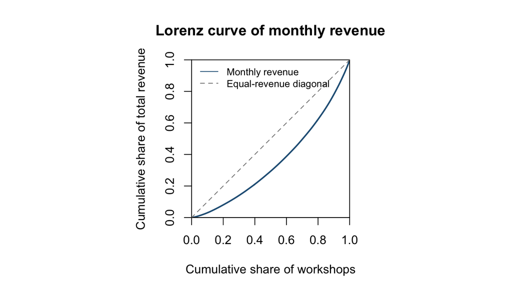

```r
x <- sort(workshops$monthly_revenue)
p <- (0:length(x)) / length(x)
q <- c(0, cumsum(x)) / sum(x)
# A square plotting region keeps both cumulative-share axes between 0 and 1.
old_pty <- par("pty")
par(pty = "s")
plot(p, q, type = "l", lwd = 2, col = "#245E85", asp = 1,
     xlim = c(0, 1), ylim = c(0, 1), xaxs = "i", yaxs = "i",
     main = "Lorenz curve of monthly revenue",
     xlab = "Cumulative share of workshops",
     ylab = "Cumulative share of total revenue")
abline(0, 1, lty = 2, col = "grey50")
legend("topleft", c("Monthly revenue", "Equal-revenue diagonal"),
       col = c("#245E85", "grey50"), lty = c(1, 2), bty = "n", cex = 0.8)
```

```r
par(pty = old_pty)

# Trapezoids give the area under the empirical Lorenz curve.
area <- sum(diff(p) * (head(q, -1) + tail(q, -1)) / 2)
gini <- 1 - 2 * area
print(c(Lorenz_area = area, Gini_index = gini))
```

```
## Lorenz_area  Gini_index
##   0.3519760   0.2960479
```

```r
# For 320 workshops, these groups contain exactly 160 and 32 observations.
bottom_n <- length(x) / 2
top_n <- length(x) / 10
bottom50_share <- sum(head(x, bottom_n)) / sum(x)
top10_share <- sum(tail(x, top_n)) / sum(x)
print(data.frame(
  Group = c("Bottom 50%", "Top 10%"),
  Workshops = c(bottom_n, top_n),
  Revenue_share = c(bottom50_share, top10_share),
  Revenue_percent = 100 * c(bottom50_share, top10_share)
))
```

```
##        Group Workshops Revenue_share Revenue_percent
## 1 Bottom 50%       160     0.2936911        29.36911
## 2    Top 10%        32     0.2195749        21.95749
```

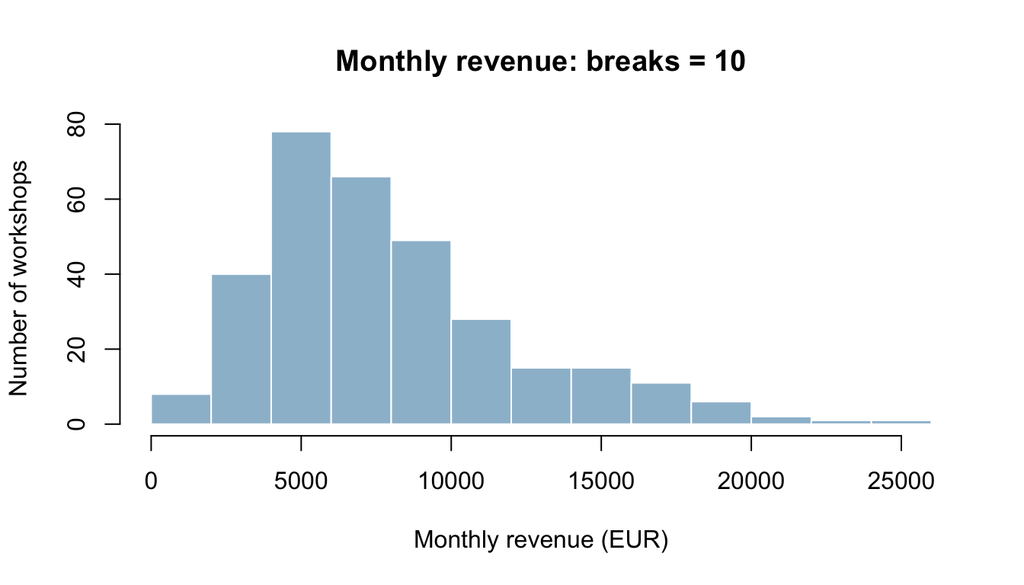

```r
h10 <- hist(revenue, breaks = 10, col = "#9DBDD2", border = "white",
            main = "Monthly revenue: breaks = 10",
            xlab = "Monthly revenue (EUR)", ylab = "Number of workshops")
```

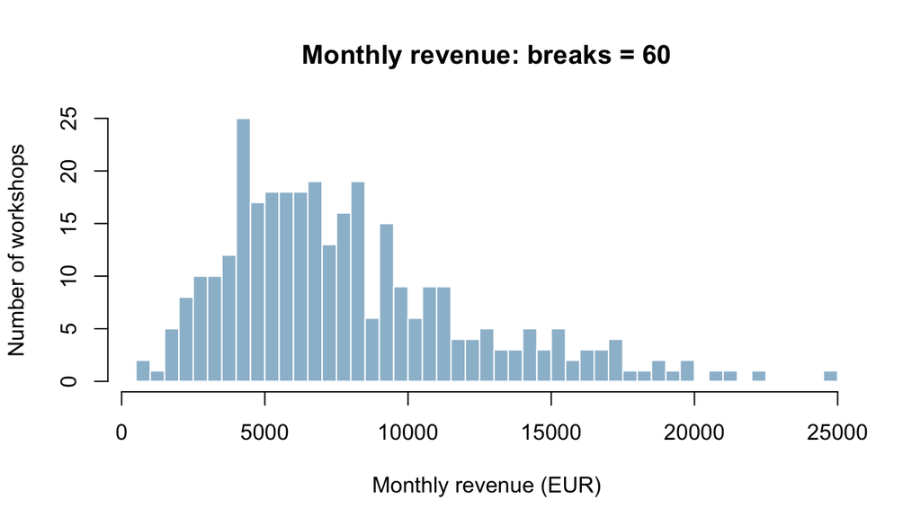

```r
h60 <- hist(revenue, breaks = 60, col = "#9DBDD2", border = "white",
            main = "Monthly revenue: breaks = 60",
            xlab = "Monthly revenue (EUR)", ylab = "Number of workshops")
```

```r
print(data.frame(
  Requested_breaks = c(10, 60),
  Actual_bins = c(length(h10$counts), length(h60$counts)),
  Bin_width_EUR = c(diff(h10$breaks)[1], diff(h60$breaks)[1])
))
```

```
##   Requested_breaks Actual_bins Bin_width_EUR
## 1               10          13          2000
## 2               60          49           500
```

> **(a)** Why can the standard deviations of `monthly_revenue` and `pieces_sold` not be compared directly, and what does the coefficient of variation change? **(b)** The observed proportions exceed the Chebyshev bounds by a wide margin. Is that a defect of the inequality, of the data, or of neither? **(c)** What does the Gini index measure that the standard deviation does not? Which of the two histograms would you use, and why is the choice not neutral?

# 4 Exercise 3 — Association between two categorical variables

1. Build the contingency table of `qualification` by `craft` and the conditional distribution of `qualification` within each craft (`prop.table(tab, margin = 2)`).
2. Compute the chi-square statistic with `chisq.test()` and Cramér’s V, $V = \sqrt{\chi^2 / (n \cdot (\min(r,c) - 1))}$.
3. Measure the dependence in mean of `price_per_piece` on `qualification` through eta-squared, the ratio of the between-group deviance to the total deviance, and draw the box-plots of `price_per_piece` by `qualification`:

```r
grand_mean  <- mean(workshops$price_per_piece)
group_means <- tapply(workshops$price_per_piece, workshops$qualification, mean)
group_n     <- table(workshops$qualification)

sum(group_n * (group_means - grand_mean)^2) /
  sum((workshops$price_per_piece - grand_mean)^2)
```

```r
tab <- table(workshops$qualification, workshops$craft)
print(tab)
```

```
##
##              Ceramics Leather Textiles Woodwork
##   Apprentice       13      43       48       31
##   Craftsman        21      32       20       31
##   Master           27      19        7       28
```

```r
conditional <- prop.table(tab, margin = 2)
print(conditional)
```

```
##
##                Ceramics    Leather   Textiles   Woodwork
##   Apprentice 0.21311475 0.45744681 0.64000000 0.34444444
##   Craftsman  0.34426230 0.34042553 0.26666667 0.34444444
##   Master     0.44262295 0.20212766 0.09333333 0.31111111
```

```r
# The supplied setup hides warnings, so capture and report any test warning.
chi_warnings <- character(0)
chi <- withCallingHandlers(
  chisq.test(tab),
  warning = function(w) {
    chi_warnings <<- c(chi_warnings, conditionMessage(w))
    invokeRestart("muffleWarning")
  }
)
print(chi)
```

```
##
##  Pearson's Chi-squared test
##
## data:  tab
## X-squared = 35.73, df = 6, p-value = 3.111e-06
```

```r
n <- sum(tab)
r <- nrow(tab)
c <- ncol(tab)
cramers_v <- sqrt(unname(chi$statistic) / (n * (min(r, c) - 1)))
print(c(Cramers_V = cramers_v))
```

```
## Cramers_V
##  0.236279
```

```r
cat("Expected counts:\n")
```

```
## Expected counts:
```

```r
print(chi$expected)
```

```
##
##              Ceramics  Leather Textiles Woodwork
##   Apprentice 25.73438 39.65625 31.64062 37.96875
##   Craftsman  19.82500 30.55000 24.37500 29.25000
##   Master     15.44063 23.79375 18.98438 22.78125
```

```r
print(c(Minimum_expected = min(chi$expected),
        Cells_below_5 = sum(chi$expected < 5),
        Cells_below_1 = sum(chi$expected < 1)))
```

```
## Minimum_expected    Cells_below_5    Cells_below_1
##         15.44063          0.00000          0.00000
```

```r
cat("All expected counts are at least 5:", all(chi$expected >= 5), "\n")
```

```
## All expected counts are at least 5: TRUE
```

```r
cat("Chi-square warnings:",
    if (length(chi_warnings)) paste(chi_warnings, collapse = "; ") else "none",
    "\n")
```

```
## Chi-square warnings: none
```

```r
cat("Each workshop has one record; independence between workshops cannot",
    "be established from the contingency table alone.\n")
```

```
## Each workshop has one record; independence between workshops cannot be established from the contingency table alone.
```

```r
grand_mean <- mean(workshops$price_per_piece)
group_means <- tapply(workshops$price_per_piece, workshops$qualification, mean)
group_n <- table(workshops$qualification)
between_deviance <- sum(group_n * (group_means - grand_mean)^2)
total_deviance <- sum((workshops$price_per_piece - grand_mean)^2)
eta_squared <- between_deviance / total_deviance
print(c(Between_group_deviance = between_deviance,
        Total_deviance = total_deviance, Eta_squared = eta_squared))
```

```
## Between_group_deviance         Total_deviance            Eta_squared
##           4.972662e+04           6.721680e+04           7.397945e-01
```

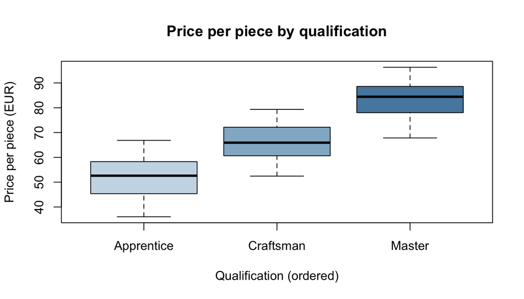

```r
boxplot(price_per_piece ~ qualification, data = workshops,
        main = "Price per piece by qualification",
        xlab = "Qualification (ordered)", ylab = "Price per piece (EUR)",
        col = c("#C9DBE8", "#91B5CD", "#5689AE"))
```

> **(a)** Why is a comparison of the raw counts not evidence of association, and which comparison is? What would independence in distribution look like in the table of conditional distributions? **(b)** Which of $\chi^2$ and $V$ would be roughly unchanged if the consortium had ten times as many workshops with the same percentage profile, and why? **(c)** Interpret the value of eta-squared in one sentence.

# 5 Exercise 4 — Association between two quantitative variables

1. Compute the Pearson and the Spearman correlation matrices for `years_active`, `price_per_piece`, `pieces_sold`, `quality_score` and `monthly_revenue` (`use = "complete.obs"`), and subtract the first from the second.
2. Plot `quality_score` against `pieces_sold` and compute the Pearson correlation of the pair.

```r
variables <- c("years_active", "price_per_piece", "pieces_sold",
               "quality_score", "monthly_revenue")
quantitative <- workshops[variables]
cat("Complete observations for both matrices:",
    sum(complete.cases(quantitative)), "of", nrow(workshops), "\n")
```

```
## Complete observations for both matrices: 309 of 320
```

```r
pearson <- cor(quantitative, method = "pearson", use = "complete.obs")
spearman <- cor(quantitative, method = "spearman", use = "complete.obs")
correlation_difference <- spearman - pearson
cat("Pearson correlation matrix:\n")
```

```
## Pearson correlation matrix:
```

```r
print(pearson, digits = 4)
```

```
##                 years_active price_per_piece pieces_sold quality_score
## years_active         1.00000         0.92493    -0.04413      -0.03094
## price_per_piece      0.92493         1.00000    -0.05259      -0.06752
## pieces_sold         -0.04413        -0.05259     1.00000      -0.12429
## quality_score       -0.03094        -0.06752    -0.12429       1.00000
## monthly_revenue      0.33184         0.39931     0.46052      -0.06826
##                 monthly_revenue
## years_active            0.33184
## price_per_piece         0.39931
## pieces_sold             0.46052
## quality_score          -0.06826
## monthly_revenue         1.00000
```

```r
cat("Spearman correlation matrix:\n")
```

```
## Spearman correlation matrix:
```

```r
print(spearman, digits = 4)
```

```
##                 years_active price_per_piece pieces_sold quality_score
## years_active         1.00000         0.96931    -0.04023      -0.07551
## price_per_piece      0.96931         1.00000    -0.06090      -0.08959
## pieces_sold         -0.04023        -0.06090     1.00000      -0.15784
## quality_score       -0.07551        -0.08959    -0.15784       1.00000
## monthly_revenue      0.38179         0.40107     0.45792      -0.06519
##                 monthly_revenue
## years_active            0.38179
## price_per_piece         0.40107
## pieces_sold             0.45792
## quality_score          -0.06519
## monthly_revenue         1.00000
```

```r
cat("Difference: Spearman minus Pearson:\n")
```

```
## Difference: Spearman minus Pearson:
```

```r
print(correlation_difference, digits = 4)
```

```
##                 years_active price_per_piece pieces_sold quality_score
## years_active        0.000000        0.044377    0.003906     -0.044570
## price_per_piece     0.044377        0.000000   -0.008310     -0.022073
## pieces_sold         0.003906       -0.008310    0.000000     -0.033551
## quality_score      -0.044570       -0.022073   -0.033551      0.000000
## monthly_revenue     0.049950        0.001762   -0.002593      0.003072
##                 monthly_revenue
## years_active           0.049950
## price_per_piece        0.001762
## pieces_sold           -0.002593
## quality_score          0.003072
## monthly_revenue        0.000000
```

```r
# Remove incomplete pairs together so the two vectors remain aligned.
pair <- workshops[complete.cases(workshops[c("quality_score", "pieces_sold")]),
                  c("quality_score", "pieces_sold")]
pair_r <- cor(pair$pieces_sold, pair$quality_score, method = "pearson")
print(c(Complete_pairs = nrow(pair), Pearson_r = pair_r))
```

```
## Complete_pairs      Pearson_r
##    309.0000000     -0.1242937
```

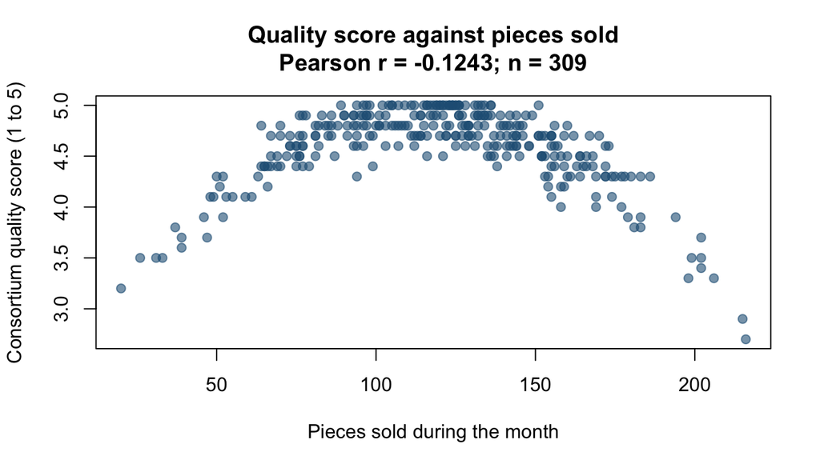

```r
plot(pair$pieces_sold, pair$quality_score,
     pch = 19, col = adjustcolor("#245E85", alpha.f = 0.6),
     main = sprintf("Quality score against pieces sold\nPearson r = %.4f; n = %d",
                    pair_r, nrow(pair)),
     xlab = "Pieces sold during the month",
     ylab = "Consortium quality score (1 to 5)")
```

> **(a)** Which variable appears in the two largest Spearman–Pearson gaps, and what does a positive gap indicate about the form of the relationship? **(b)** The correlation between `quality_score` and `pieces_sold` is close to zero. Does it follow that the two variables are unrelated?